# Tutorial1 Ch2

Ryan Huang

7/26/2019

## 0.1 Chapter 2

In ch2, the author illustrate the following idea:

$Posterior = \frac{Likelihood \times Prior}{Average Likelihood}$

by using an example of throwing a globe representing the Earth.

We are curious how much of the surface is covered in water. We toss the globe up in the air. When we catch it, we record whether or not the surface under our right index finger is water or land.

After nine tosses we get our `data`: W L W W W L W L W, (6W, 3L).

1. Goal: Estamate the proportion of water on Earth, `p`
2. How:
- Model: data generating processes in our mind
- Fit the model: different approach for estimating `p`
- Evaluation

### 0.1.1 Model

We assumed that the counts of **water** W and **land** L are distributed binomially, with probability `p` of **water** on each toss.

### 0.1.2 Fit the model

There are different methods for us to estimate what’s the most probable value of `p` - Method 1: Grid Approximation - Method 2: Stan / MCMC

#### 0.1.2.1 Grid Approximation:

The intuition of grid approximation is to try every possible value of `p` from 0 to 1, and find out the `p` with the maximum likelihood to generate such a `data`, getting 6W from 9 draws.

However, `p` is continuous. We choose some values of `p` to do experiments, this is the grid.

1. define the grid
2. define the weight of every p (`prior`)
3. calculate the likelihood using dbinom (dnorm: the likelihood of having 6W from 9 draws given p)
4. posterior = prior * likelihood
5. convert posterior to probability (standardize)

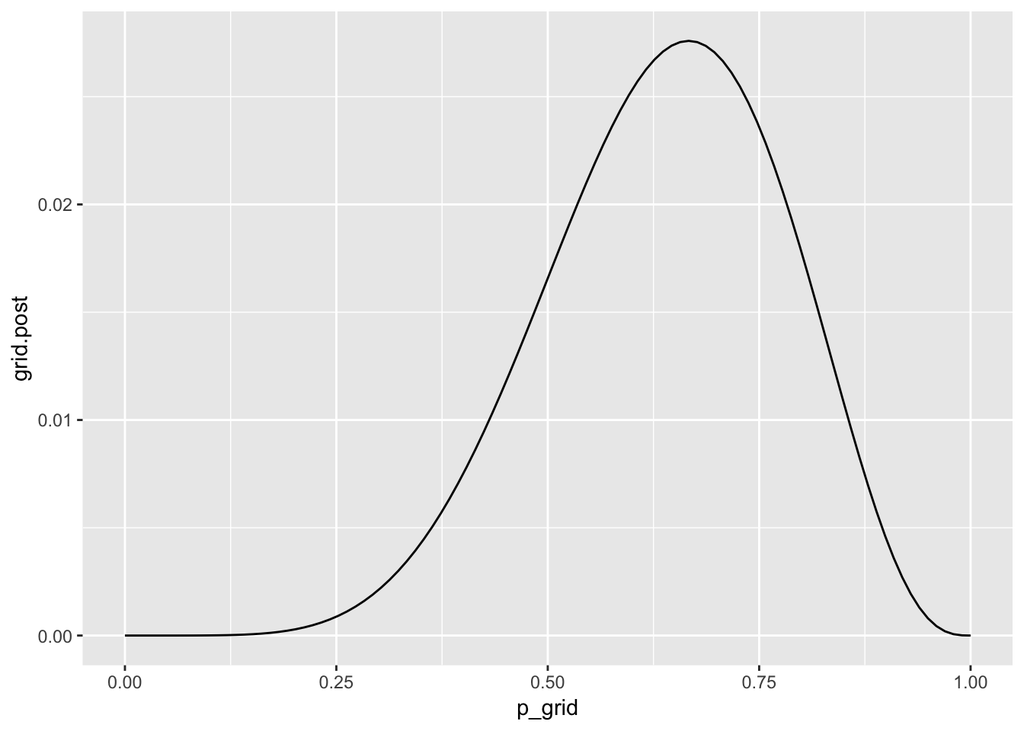

```r
d =
   tibble(
     p_grid = seq(from = 0, to = 1, length.out = 100),  # define grid
     prior  = 1) %>%                                   # define prior
   # compute likelihood at each value in grid
   mutate(
     grid.likelihood = dbinom(6, size = 9, prob = p_grid)) %>%
   # compute product of likelihood and prior
   mutate(
     grid.unstd_post = grid.likelihood * prior) %>%
   # standardize the posterior, so it sums to 1
   mutate(
     grid.post  = grid.unstd_post / sum(grid.unstd_post))

d %>%
  ggplot(aes(p_grid, grid.post)) +
  geom_line(size=.5)
```

#### 0.1.2.2 Stan / MCMC:

There is another approach called MCMC. MCMC will draw lots of samples from the posterior, so we can calculate the count of samples in each p_grid to compare result of grid approximation.

Firstly, we write down the model on our own. Recall Tutorial 0.3, there are 3 required code blocks:

1. **data**: 6W, 3L
2. **parameters**: `p`
3. **model**:
- prior - P: unifrom
- likelihood - W: binomial distribution;

```r
binom.model = "
data {
    int N; // number of data
    int W; // number of w observations
}
parameters {
    real<lower=0, upper=1> p;
}
model {
    p ~ uniform(0,1);
    W ~ binomial(N, p);
}
"
binom.data = list(N = 9, W = 6)
binom.fit = stan(model_code = binom.model,
                 data = binom.data,
                 chains = 2,
                 iter = 5000)
```

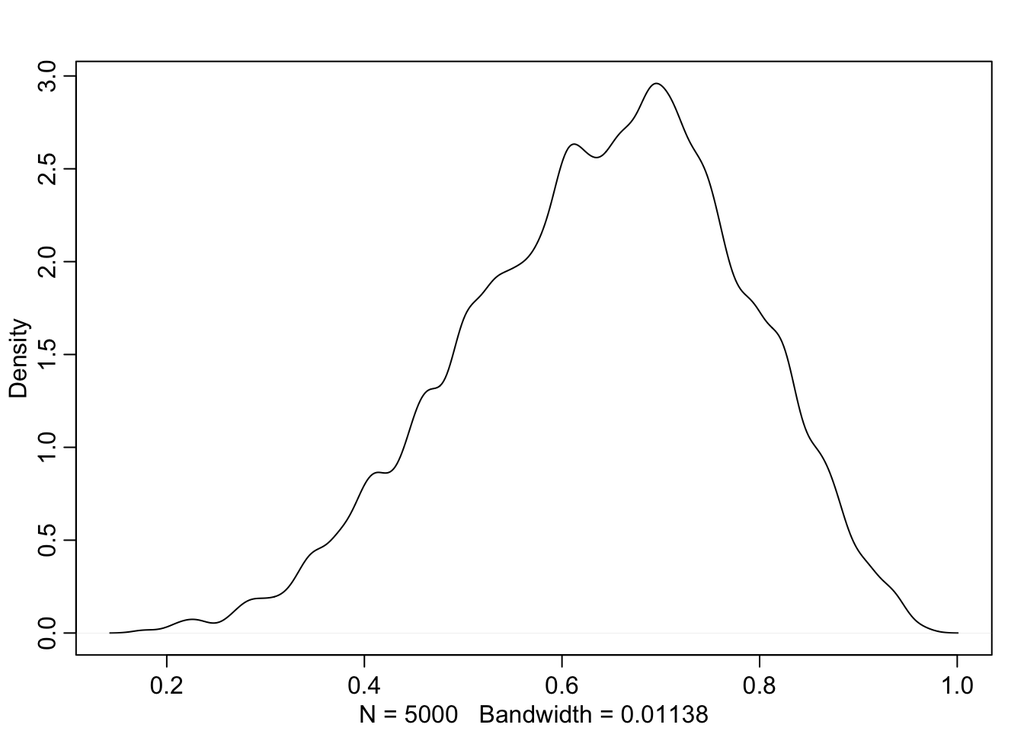

```r
# use rethinking::dens to plot the posterior distribution
binom.post = as.data.frame(binom.fit)
dens(binom.post$p)
```

#### 0.1.2.3 Compare MCMC and grid approximation:

Intuition: Convert count of samples to relative probability.

1. Calculate the count of samples in each p_grid
2. Convert to probability
3. Use `geom_col` to plot a histogram and compare it with result from grid.

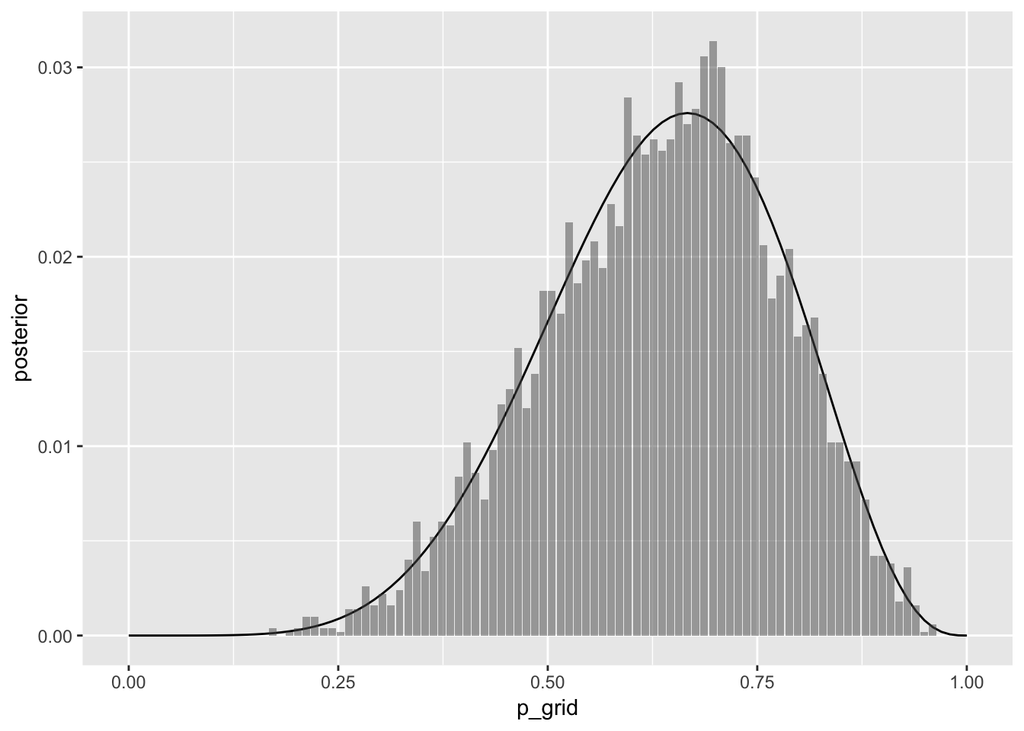

```r
# check: https://www.r-bloggers.com/counts-numbers-in-a-interval/
a = binom.post$p %>%
  hist(breaks = seq(from=0, to=1, length.out = 100), plot = F) %>%
  .$counts %>%
  c(.,0)

d = d %>% mutate(MCMC.post = a / sum(a))

d %>% ggplot()+
  geom_line(aes(p_grid, grid.post))+
  geom_col(aes(p_grid, MCMC.post), alpha = 0.5)+
  labs(x='p_grid', y='posterior')
```